# Régression logistique multivariée

EP - FOUILLE DE DONNEES AVEC R - Bertrand Roudier - ESIEE Paris

### 1. Introduction

La régression logistique multivariée est une méthode très utilisée en apprentissage statistique. Ce TD a pour objectif:

1. De réaliser, dans un premier temps, une régression logistique sur un modèle plein (avec toutes les variables)
   - d’utiliser le test de Wald sur une ou plusieurs variables pour évaluer leur pertinence au sein du modèle,
   - de réaliser et d’interpréter une courbe roc (les résultats). Son utilisation permettra, à l’aide de l’indice de Youden, de déterminer un seuil optimal.
2. De réaliser une régression logistique progressive afin de sélectionner les variables pertinentes,
3. De réaliser, sur les variables sélectionnées à partir de la régression ascendente, une régression logistique en validation croisée qui nous permettra, sur l’ensemble des jeux tests, d’estimer un seuil moyen “optimal”,

#### 1.1 Les librairies

- Les nouvelles librairies à télécharger sont les suivantes :
  - Le package *MASS* est utilisé pour réaliser la sélection progressive des variable à l’aide de la fonction *stepAIC*,
  - Le package *aod* est utilisé pour réaliser le test de Wald à l’aide de la fonction *wald.test*,
  - Le package *kableExtra* est un nouveau package permettant la visualisation des tableaux

```r
rm(list = ls())

LoadPack <- function(Packrequired)
{
  for(i in 1:length(Packrequired))
  {
    if(require(Packrequired[i], character.only = TRUE) == FALSE){install.packages(Packrequired[i])}
    library(Packrequired[i],character.only = TRUE)
  }
  print('Package ... DONE')
}

pack <- c('ggplot2','caret', 'readr','pROC','reshape2', 'MASS', 'aod', 'kableExtra' )

#-> chargement des packages
LoadPack(pack)
```

#### 1.2 Les données

- Nous reprenons les données du fichier *Hearh_clinical_records_dataset*
- Pour réaliser la régression logistique, le formatage des données est le suivant :

```r
head(dfw) %>% kbl() %>%  kable_styling( position = "center", full_width = FALSE)
```

| age | cpk | frac | platelets | creat | Na | time | anaemia | diabetes | hbp | smoking | sex | event |
| --- | --- | --- | --- | --- | --- | --- | --- | --- | --- | --- | --- | --- |
| 75 | 582 | 20 | 265000 | 1.9 | 130 | 4 | Non | Non | Oui | Non | H | vv |
| 55 | 7861 | 38 | 263358 | 1.1 | 136 | 6 | Non | Non | Non | Non | H | vv |
| 65 | 146 | 20 | 162000 | 1.3 | 129 | 7 | Non | Non | Non | Oui | H | vv |
| 50 | 111 | 20 | 210000 | 1.9 | 137 | 7 | Oui | Non | Non | Non | H | vv |
| 65 | 160 | 20 | 327000 | 2.7 | 116 | 8 | Oui | Oui | Non | Non | F | vv |
| 90 | 47 | 40 | 204000 | 2.1 | 132 | 8 | Oui | Non | Oui | Oui | H | vv |

### 2. Régression logistique multivariée modéle plein

Dans un premier temps, nous effectuons la régression logistique en incluant la totalité des variables. Nous utilisons la fonction *glm*

- pour signifier les variables à inclure dans le modèle, nous utilisons la fonction *as.formula* qui permet de convertir un texte en une formule explicite.
  - L’expression *event ~ age + cpk + frac platelets + creat + Na + time + anaemia + diabetes + hbp + smoking + sex* signifie que l’estimation de la variable *event* est réalisée en prenant en compte les variables *age, cpk, frac, platelets, creat, Na, time, anaemia, diabetes, hbp, smoking, sex*.
- pour signifier le modèle logistique , l’argument *family* est : *family=binomial(link=logit)*.
- Pour des raisons de lisibilité, le dataframe *dfw* est renommé par *XY*

Le code est le suivant:

```r
#-> recherche automatique de l'identifiant de la variable à prédire
pred_name <- 'event'
id_pred   <- which(names(dfw) %in% pred_name)
#-> on renomme de dataframe
XY        <- dfw
#-> construction du modèle
full_form  <- as.formula(paste0(names(dfw)[id_pred], ' ~ ', paste0(names(dfw)[-id_pred], collapse = ' + ')))
#-> rmq : on aurait pu aussi utiolser une formule bcp plus simple ( mais moins lisible)
# ..... ful_form <- as.formula('event ~.')
#-> on appelle la règression logistique (qui est un modèle linéaire général)
full_model <- glm(event ~., family=binomial(link=logit), data = dfw)
```

- la fonction *glm* retourne une liste dont les éléments importants sont fournis par *summary(full_model)* :

```r
summary(full_model)
```

```
##
## Call:
## glm(formula = event ~ ., family = binomial(link = logit), data = dfw)
##
## Deviance Residuals:
##     Min       1Q   Median       3Q      Max
## -2.1848  -0.5706  -0.2401   0.4466   2.6668
##
## Coefficients:
##               Estimate Std. Error z value Pr(>|z|)
## (Intercept)  1.018e+01  5.657e+00   1.801 0.071774 .
## age          4.742e-02  1.580e-02   3.001 0.002690 **
## cpk          2.222e-04  1.779e-04   1.249 0.211684
## frac        -7.666e-02  1.633e-02  -4.695 2.67e-06 ***
## platelets   -1.200e-06  1.889e-06  -0.635 0.525404
## creat        6.661e-01  1.815e-01   3.670 0.000242 ***
## Na          -6.698e-02  3.974e-02  -1.686 0.091855 .
## time        -2.104e-02  3.014e-03  -6.981 2.92e-12 ***
## anaemiaOui  -7.470e-03  3.605e-01  -0.021 0.983467
## diabetesOui  1.451e-01  3.512e-01   0.413 0.679380
## hbpOui      -1.027e-01  3.587e-01  -0.286 0.774688
## smokingOui  -1.349e-02  4.126e-01  -0.033 0.973915
## sexH        -5.337e-01  4.139e-01  -1.289 0.197299
## ---
## Signif. codes:  0 '***' 0.001 '**' 0.01 '*' 0.05 '.' 0.1 ' ' 1
##
## (Dispersion parameter for binomial family taken to be 1)
##
##     Null deviance: 375.35  on 298  degrees of freedom
## Residual deviance: 219.55  on 286  degrees of freedom
## AIC: 245.55
##
## Number of Fisher Scoring iterations: 6
```

#### 2.1 Coefficients de régression

- le terme *Deviance Residuals* ; retourne les quantiles des différences entre les probabilités observées et les probabilités calculées de la variable à expliquer (event).
- La première colonne du tableau correspond à l’estimation des coefficients ${{\hat \beta }_0}$ et ${{\hat \beta }_{_j}}$ de l’équation logistique :
  $$\pi (x) = \frac{1}{{1 + {e^{ - \left( {{\beta _0} + \sum\limits_{j = 1}^p {{\beta _j}{X_j}} } \right)}}}}$$

##### 2.1.1 Inférence statistique

- Sous hypothèse de normalité les z scores (colonne 3) : $Z = \frac{{{{\hat \beta }_{_j}}}}{{s({\beta _{_j}})}} \to N(0,1)$ suivent une distribution normale.
- Il est donc possible de réaliser une inférence permettant de tester, pour chaque variable, leur degrés de signification (de participation) dans le modèle . L’inférence est la suivante :

$$\left\{ \begin{array}{l}
{H_0}:{\beta _{_j}} = 0\\
{H_1}:{\beta _{_j}} \ne 0
\end{array} \right.$$

- L’acceptation de H0 signifie que la variable ne participe pas de façon significative à l’estimation de y. Ce test nous fournit une première indication sur l’implication des variables dans l’estimation de la variable à expliquer. Cependant, ce test ne fournit pas de renseignements sur l’apport **d’une variable par rapport aux autres** dans l’estimation de la variable à expliquer. Il est donc nécessaire de réaliser un test de Wald

##### 2.1.2 Intervalles de confiance

- La fonction *confint.default* permet de calculer les limites l’intervalle de confiance en bilatéral (95%) associé aux paramètres de la régression

```r
head(confint.default(full_model) )  %>% kbl(booktabs = TRUE) %>% kable_styling( position = "center", full_width = FALSE)
```

|  | 2.5 % | 97.5 % |
| --- | --- | --- |
| (Intercept) | -0.9017451 | 21.2716031 |
| age | 0.0164504 | 0.0783877 |
| cpk | -0.0001265 | 0.0005710 |
| frac | -0.1086670 | -0.0446580 |
| platelets | -0.0000049 | 0.0000025 |
| creat | 0.3103744 | 1.0218123 |

#### 2.2 Test de Wald

- Le test de Wald permet de realiser différents tests sur les coefficients des variables en prenant en compte le lien (matrice des variances covariance) entre ces dernières. A titre d’exemple nous testons s’il existe une différence entre les coefficients age et Na. Nous affectons le code 1 pour l’age et - 1 pour Na, car nous testons une différence (cette méthode est appelée méthode des constrastes):

```r
 t <- rbind(rep(0,13)) ; t[2] <- 1 ; t[7] <- -1
 wald.test ( b  =  coef (full_model),  Sigma  =  vcov (full_model),  L  = t)
```

```
## Wald test:
## ----------
##
## Chi-squared test:
## X2 = 7.3, df = 1, P(> X2) = 0.007
```

```r
 wald.test ( b  =  coef (full_model),  Sigma  =  vcov (full_model),  Terms  = c(4,7))
```

```
## Wald test:
## ----------
##
## Chi-squared test:
## X2 = 25.0, df = 2, P(> X2) = 3.7e-06
```

- Le résultat ci dessus montrent que ces coefficient participent **concomitamment** de manière très significative à l’estimation de la variable prédictive.

#### 2.3 Performance du classifieur

- La courbe ROC permet d’évaluer les performances d’un classifieur binaire, c’est-à-dire d’un système qui a pour objectif de catégoriser des éléments en deux groupes distincts sur la base d’une ou plusieurs des caractéristiques de chacun de ces éléments. Un article intéressant sur les applications de la courbe ROC en biologie [ici](http://www.reseau-naissance.fr/data/mediashare/t3/pr3xql3uzbdbgvdkpemed657ohvpki-org.pdf.)
- La courbe ROC est une représentation graphique de la relation existante entre la sensibilité et la spécificité d’un test pour toutes les valeurs seuils possibles. L’ordonnée représente la sensibilité et l’abscisse correspond à la quantité (1- spécificité).
- De manière synthétique il s’agit de tracer l’évolution en fonction des seuils de la proportion entre vrais positifs et la proportion de faux positifs. Si la relation entre les deux proportions est égale à 1 (droite) l’AUC = 0.5. Dans ces conditions, la proportion entre vrais positifs et faux positifs sera identique et le prédicteur (algorithme : reg logistique pas exemple) ne fera pas mieux que le hasard. Plus l’aire sous courbe sera supérieure à 0.5, plus l’algoritme sera plus performant : % de détection des VP > % de détection des FP.
- Un des apports majeurs de la courbe ROC est la possibilité de calculer le seuil optimal de détection (vv versus dcd). Ce dernier est essentiel pour le calcul de la matrice des confusions et donc pour l’évaluation des performances de l’algoritme (régression logistique dans notre cas). Il existe plusieurs indices permettant de calculer les seuils. Nous utiliserons l’indice de Youden qui est simple à calculer et performant (cf. cours). Ce dernier correspond au point de la courbe le plus éloigné de la diagonale (AUC = 0.5).
- Cepandant, la recherche du seuil (choix de l’indice) néssecite la prise en compte de données épidémiologiques.
  - la prévalence (% de vivant : annotations ) ne doit pas trop s’éloigner de 50%.
  - L’intéret médicaux économique : A titre d’exemple : Si une maladie possède un traitement onéreux aux effets secondaires potentiellement graves, il convient de limiter au maximum le nombre de faux positifs, donc de choisir une spécificité élevée. La valeur seuil sera située dans ce cas dans la partie inférieure gauche de la courbe ROC. À l’inverse, certaines maladies possèdent des complications graves qui peuvent être évitées si un traitement simple est mis en place précocement : le test doit posséder une sensibilité élevée. La valeur seuil se situera au niveau de la partie supérieure droite de la courbe ROC.

#### 2.4 Courbe Sen Spe vs seuil

###### 2.4.1 Script

```r
Valid_ROC <- function(obs, pred, direction = 0, threshold  = NULL, graph = T)
{
  require(pROC)
  require(caret)
  if(!is.factor(obs)){obs <- factor(obs)}
  lev        <- levels(obs)
  data_logit <- data.frame(obs = factor(obs), pred = pred)
  data_roc   <- roc(obs,pred)
  cir        <- ci(data_roc)
  data_spec  <- data.frame( sens    = data_roc$sensitivities ,
                            spec    = data_roc$specificities ,
                            thr     = data_roc$thresholds    ,
                            youden  = data_roc$sensitivities + data_roc$specificities - 1
                           )
  cir <- data.frame(roc = c(cir, youden = max(data_spec$youden) )) ; rownames(cir) <-c('AUC_lower','AUC','AUC_upper','youden')
  #-> si argument nulle alors calcul du seuil par la méthode de Youden
  if (is.null(threshold))
  {
    id       <- which.max(data_spec$youden) ; data_spec[id,] ;
    best_thr <- data_spec[id,3]
  }else{best_thr <- threshold}
  #-> binarisation
  if(direction == 0){dir_name <- lev[1] ; ndir_name <- lev[2] }else{dir_name = lev[2] ; ndir_name <- lev[1]}
  fac_roc    <- rep(dir_name,nrow(data_logit))
  id         <- which(pred >= best_thr) ; fac_roc[id] <- ndir_name ; fac_roc <- factor(fac_roc)
  conf_mat_1 <- confusionMatrix(fac_roc, obs)
  result     <- data.frame(Confusion = c(                 conf_mat_1$overall[1],
                                                          conf_mat_1$overall[3],
                                                          conf_mat_1$overall[4],
                                                          conf_mat_1$byClass[1],
                                                          conf_mat_1$byClass[2],
                                                          conf_mat_1$byClass[3],
                                                          conf_mat_1$byClass[4],
                                                          conf_mat_1$byClass[7],
                                                          Threshold  = best_thr
                                          )
                         )
  all_result <- list( result = result, Confusion = conf_mat_1$table, roc = cir)
  #--> graphique
  if(graph)
    {  data_gr    <- melt(data_spec, id.vars = 'thr')
       gr         <- ggplot(data = data_gr) + geom_line(aes(x = thr, y = value, color = variable )) +
       ylab('Probability') + xlab('threshold') + theme(legend.title = element_blank()) + geom_vline( xintercept = best_thr, color = '#0066CC')
      #--> courbe roc
      plot.roc(data_roc, print.auc=TRUE, print.thres=TRUE,col="#0066CC")
      all_result[['graph']] <- gr
  }
      return( all_result)
}
result <- Valid_ROC(XY$event, full_model$fitted.values, graph = F)
```

###### 2.4.2. Résultats

- La fonction *Valid_ROC* utilise les librairies *pROC* et *caret*. Elle calcule :
  - l’AUC et trace le courbe ROC à la conditon que l’argument **graph = T**
  - le seuil optimal (best_thr : cf. code) à l’aide de l’indice de Youden (à la condition que l’argument **threshold = NULL**. Si cet argument est différent (0 < threshold < 1), le seuil optimal correspondra à la valeur de l’argument)
  - la matrice de confusion au seuil optimal.
- La fonction retourne les élements suivants :
  - le data frame *roc* qui fournit : (i) l’AUC, (ii) les intervalles de confiance, (iii) l’indice optimal de Youden

|  | roc |
| --- | --- |
| AUC_lower | 0.8609739 |
| AUC | 0.8972188 |
| AUC_upper | 0.9334637 |
| youden | 0.6459873 |

- le data frame *result* qui fournit les différents paramètres de la matrice des confusions calculés à partir du seuil optimal

|  | Confusion |
| --- | --- |
| Accuracy | 0.8528428 |
| AccuracyLower | 0.8075265 |
| AccuracyUpper | 0.8909955 |
| Sensitivity | 0.9064039 |
| Specificity | 0.7395833 |
| Pos Pred Value | 0.8803828 |
| Neg Pred Value | 0.7888889 |
| F1 | 0.8932039 |
| Threshold | 0.4591677 |

- La matrice des confusions au seuil optimal

|  | dcd | vv |
| --- | --- | --- |
| dcd | 184 | 25 |
| vv | 19 | 71 |

###### c. Les grahiques

- Le graphique ci dessous fournit: (i) la courbe ROC avec l’AUC, la valeur du seuil (+ IC) calculé à partie de l’indice de Youden

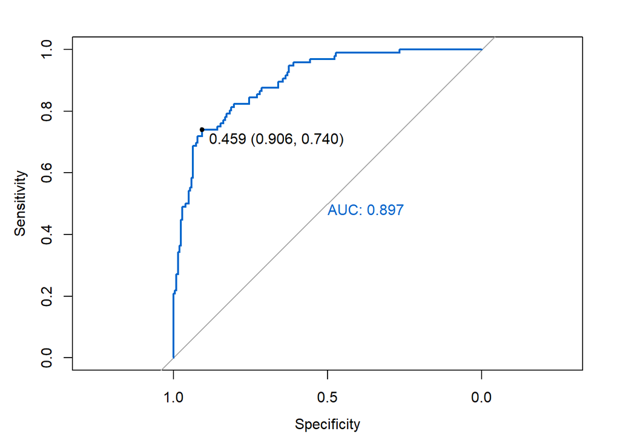

- Le second graphique est aussi intéressant car il montre l’évolution des spécificités et des sensibilités an fonction des valeurs de seuil. Il montre aussi l’évolution de l’indice de Youden en fonction des seuils.
  - dans le cadre de cette analyse, l’indice Youden privilégie la spécificité au profil de la sensibilité. Il est bien évidemment possible de modifier le seuil en fonction des priorités de l’étude (privilégier le sensibilité ou la spécificité, ou un “équilibre” entre les deux)

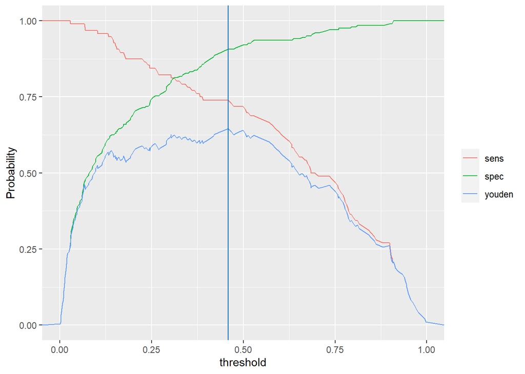

### 3. Régression logistique ascendente

#### 3.1 Rappels

- Comme nous l’avons vu lors de l’analyse des z scores, certains coefficients des variables ne semblent pas pertinents (non significatifs).
- La sélection progressive des variables se fait en calculant le rapport de vraisemblance entre les modéles à p variables et p + 1 variables. Aprés avoir calculer le rapport, on validera l’inclusion de la nouvelle variable à l’aide d’un test de Wald. Si le test conclue à une acceptation H0 (egalité des modèles à p et p +1 variable), l’apport de la variable (en terme du rapport de vraisemblance) est faible et donc la variable n’améliorera pas la prédiction. En conséquence, elle ne sera pas rajoutée au modèle.
- La fonction *stepAIC* du package MASS réalise automatiquemnt la procédure d’inclusion et fournit le modèle avec les variables retenues (donc pertinentes pour l’estimation de la prédiction)

#### 3.2 Descrition de la méthode

- L’utilisation de la fonction stepAIC nécessite en amont quelques calculs préliminaires
  - la mise en forme des modéles plein et modèles vides en utilisant la fonction *as.formula* que nous avons déjà utilisé au paragraphe 2 (pour le modèle plein)
  - Le calcul des régressions logistiques sur le modèle vide et le modèle plein. Le code est le suivant :

```r
 empty_form    <- as.formula(paste0(names(dfw)[id_pred] ,'~1'))
 full_form     <- as.formula(paste0(names(dfw)[id_pred], ' ~ ', paste0(names(dfw)[-id_pred], collapse = ' + ')))
 empty_model   <- glm(empty_form , family=binomial(link=logit), data = XY)
 full_model    <- glm(full_form  , family=binomial(link=logit), data = XY)
 forward_model <-  stepAIC(empty_model,direction = 'forward',  scope = list(upper = full_model), trace = F)
 summary(forward_model)
```

```
##
## Call:
## glm(formula = event ~ time + frac + creat + age + Na, family = binomial(link = logit),
##     data = XY)
##
## Deviance Residuals:
##     Min       1Q   Median       3Q      Max
## -2.1590  -0.5888  -0.2281   0.5144   2.7959
##
## Coefficients:
##              Estimate Std. Error z value Pr(>|z|)
## (Intercept)  9.493034   5.405768   1.756  0.07907 .
## time        -0.020895   0.002916  -7.166 7.74e-13 ***
## frac        -0.073430   0.015785  -4.652 3.29e-06 ***
## creat        0.685990   0.174044   3.941 8.10e-05 ***
## age          0.042466   0.015030   2.825  0.00472 **
## Na          -0.064557   0.038377  -1.682  0.09254 .
## ---
## Signif. codes:  0 '***' 0.001 '**' 0.01 '*' 0.05 '.' 0.1 ' ' 1
##
## (Dispersion parameter for binomial family taken to be 1)
##
##     Null deviance: 375.35  on 298  degrees of freedom
## Residual deviance: 223.49  on 293  degrees of freedom
## AIC: 235.49
##
## Number of Fisher Scoring iterations: 6
```

##### 3.2.1 Résultats

```r
result_forward <- Valid_ROC(XY$event, forward_model$fitted.values, graph = F)
```

- L’AUC :

|  | roc |
| --- | --- |
| AUC_lower | 0.8557927 |
| AUC | 0.8935242 |
| AUC_upper | 0.9312557 |
| youden | 0.6635878 |

- La matrice des confusions au seuil optimal

|  | dcd | vv |
| --- | --- | --- |
| dcd | 177 | 20 |
| vv | 26 | 76 |

- Spécificité et Sensibilité :

|  | Confusion |
| --- | --- |
| Accuracy | 0.8461538 |
| AccuracyLower | 0.8001752 |
| AccuracyUpper | 0.8851110 |
| Sensitivity | 0.8719212 |
| Specificity | 0.7916667 |
| Pos Pred Value | 0.8984772 |
| Neg Pred Value | 0.7450980 |
| F1 | 0.8850000 |
| Threshold | 0.3901537 |

##### 3.2.2 Courbe ROC

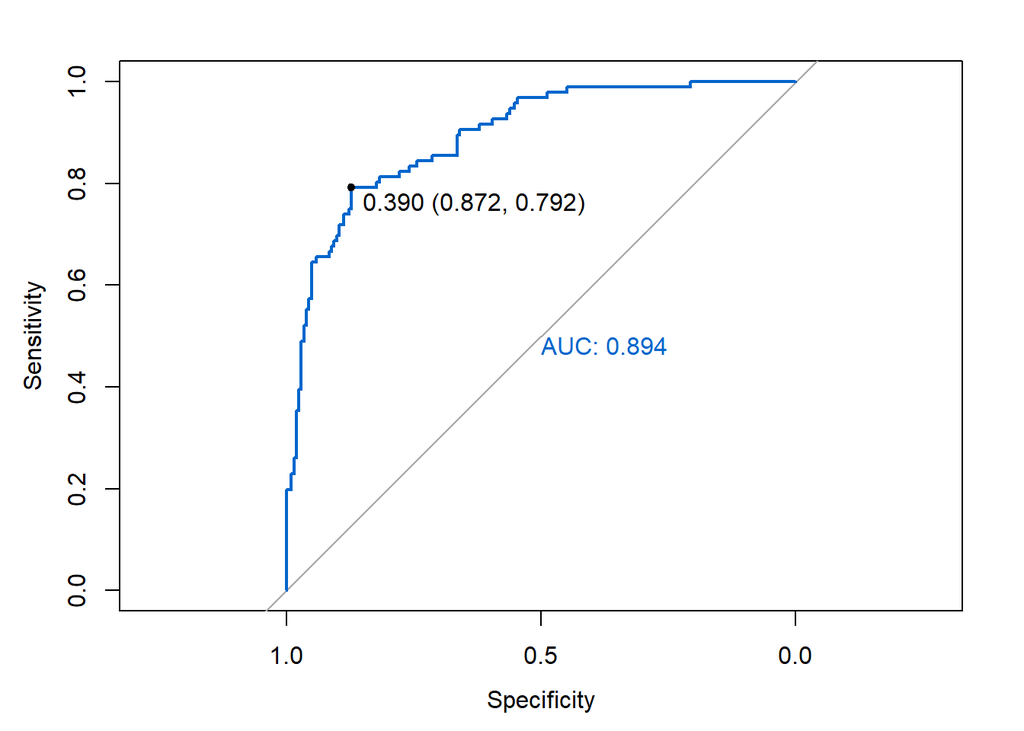

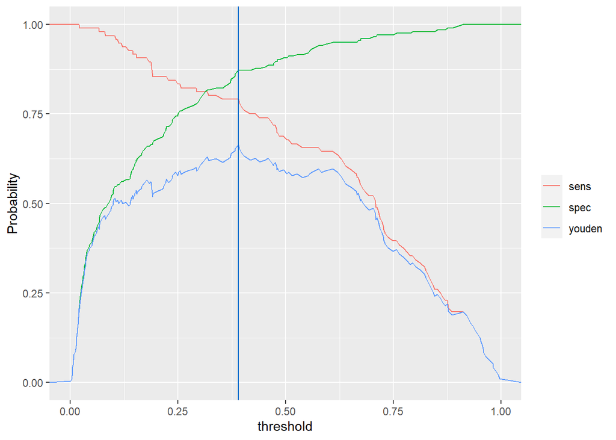

#### 3.4 Comparaison des résultats

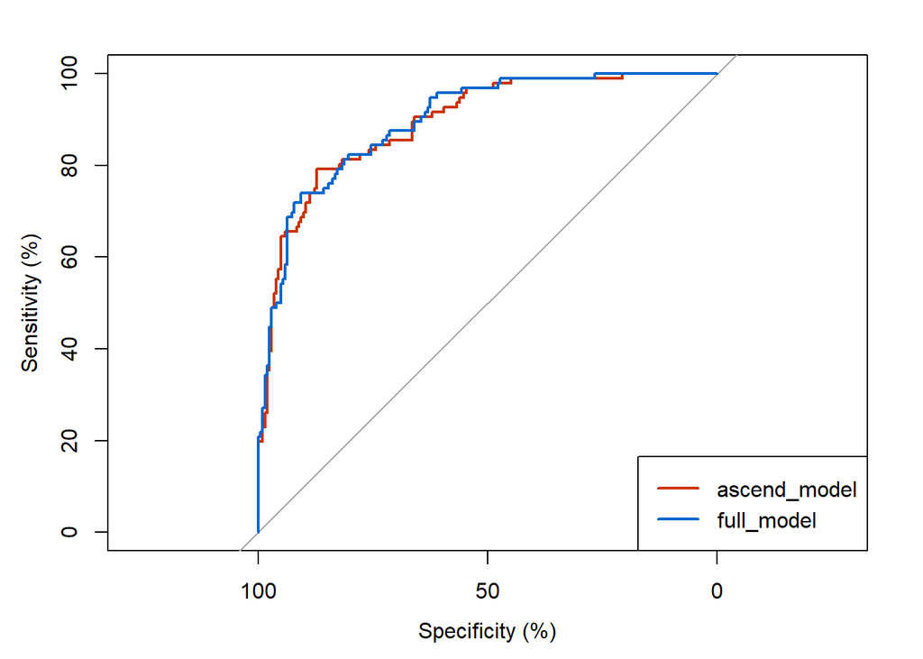

```r
roc1 <- plot.roc(factor(XY$event),forward_model$fitted.values, percent = T, col = '#CC3300')
roc2 <- lines.roc(factor(XY$event),full_model$fitted.values, percent=T, col="#0066CC",  print.thres=TRUE)
legend("bottomright", legend=c("ascend_model", "full_model"), col=c('#CC3300', "#0066CC"), lwd=2)
```

- En utilisant les seuils calculés par l’indice de Youden, les résultats sont les suivants :

|  | full | ascend |
| --- | --- | --- |
| Accuracy | 0.8528428 | 0.8461538 |
| AccuracyLower | 0.8075265 | 0.8001752 |
| AccuracyUpper | 0.8909955 | 0.8851110 |
| Sensitivity | 0.9064039 | 0.8719212 |
| Specificity | 0.7395833 | 0.7916667 |
| Pos Pred Value | 0.8803828 | 0.8984772 |
| Neg Pred Value | 0.7888889 | 0.7450980 |
| F1 | 0.8932039 | 0.8850000 |
| Threshold | 0.4591677 | 0.3901537 |

- On remarque que la sensibilité est un peu plus faible avec le modèle ascendant (0.90 vs 0.87) et la spécificité un peu élevée. La précision est très légèrement plus faible avec le modèle ascendant.
  - pour le modèle plein , le nombre de FN = 25 et le nombre de FP = 19, le nombre VP + VN = 255
  - pour le modèle ascendant, le nombre de FN = 20 et le nombre de FP = 26, le nombre VP + VN = 253

### 4. Validation croisée

#### 4.1 Les objectifs

##### 4.1.1 Les Résultats

- Nous concaténons les résultats puis nous en calculons les moyennes. Les résultats sont les suivants :
- rmq: en fonction de la randomisation les résultats peuvent être légérement différent !
- Les tableaux suivants fournissent les résultats obtenus pour chaque partition :

|  | kfold_1 | kfold_2 | kfold_3 | kfold_4 | kfold_5 |
| --- | --- | --- | --- | --- | --- |
| AUC_lower | 0.837852 | 0.8233818 | 0.8180192 | 0.8417495 | 0.6459956 |
| AUC | 0.912500 | 0.9010989 | 0.9096296 | 0.9127764 | 0.7791005 |
| AUC_upper | 0.987148 | 0.9788160 | 1.0000000 | 0.9838033 | 0.9122054 |
| youden | 0.725000 | 0.6630037 | 0.7555556 | 0.6756757 | 0.4761905 |

|  | kfold_1 | kfold_2 | kfold_3 | kfold_4 | kfold_5 |
| --- | --- | --- | --- | --- | --- |
| Accuracy | 0.8500000 | 0.8666667 | 0.9166667 | 0.7966102 | 0.7666667 |
| AccuracyLower | 0.7342596 | 0.7540778 | 0.8161422 | 0.6716698 | 0.6396172 |
| AccuracyUpper | 0.9290438 | 0.9406356 | 0.9723867 | 0.8902463 | 0.8661627 |
| Sensitivity | 0.8250000 | 0.9487179 | 0.9555556 | 0.6756757 | 0.8095238 |
| Specificity | 0.9000000 | 0.7142857 | 0.8000000 | 1.0000000 | 0.6666667 |
| Pos Pred Value | 0.9428571 | 0.8604651 | 0.9347826 | 1.0000000 | 0.8500000 |
| Neg Pred Value | 0.7200000 | 0.8823529 | 0.8571429 | 0.6470588 | 0.6000000 |
| F1 | 0.8800000 | 0.9024390 | 0.9450549 | 0.8064516 | 0.8292683 |
| Threshold | 0.2720257 | 0.5572248 | 0.3926258 | 0.1677035 | 0.5603273 |

- Les moyennes et les écart types des paramètres sont les suivants

|  | mean | sd |
| --- | --- | --- |
| Accuracy | 0.8393220 | 0.0590488 |
| AccuracyLower | 0.7231533 | 0.0695619 |
| AccuracyUpper | 0.9196950 | 0.0419382 |
| Sensitivity | 0.8428946 | 0.1154200 |
| Specificity | 0.8161905 | 0.1358437 |
| Pos Pred Value | 0.9176210 | 0.0623640 |
| Neg Pred Value | 0.7413109 | 0.1251162 |
| F1 | 0.8726428 | 0.0557855 |
| Threshold | 0.3899814 | 0.1734330 |

|  | mean | sd |
| --- | --- | --- |
| AUC_lower | 0.7933996 | 0.0829860 |
| AUC | 0.8830211 | 0.0582853 |
| AUC_upper | 0.9723945 | 0.0345465 |
| youden | 0.6590851 | 0.1088489 |

##### 4.1.2 Conclusion

- comparaison des résultats Specificité, Sensibilité, Seuil ?